# Ankylosing Spondylitis Case Study Report

Group1: Jiacheng Chen, Xigang Zhang, Yiyun Gong

November 9, 2020

# Project Description

Royal National Hospital(RNH) for Rheumatic Diseases in Bath holds a study to test if daily stretching hip joints would help patients with Ankylosing spondylitis(AS) which is a disease that chronic form of arthritis limiting the motion of the spine and muscles can perform at a wider angle in their hip joints.

RNH conducted three weeks long randomized testing in which thirty-nine consecutive admitted patients who have “typical” AS were randomly allocated to a control group and a treatment group. The control group received the standard treatement and the treatment group received additional stretching exerices. Patients were twice as likely to be allocated to the treatment group. As the result, The number of patients in the treatment group is twenty-seven and the number of patients in the control group is twelve. This study only concerned flexion and rotation of hips as measurements in degrees and an increase represent an improvement.

Client provided raw data from the experiment(see Appendix A for raw data set description) and wanted us to analyze the data to determine if stretch will help AS patients to get more movement in hip joints, i.e are stretch both improve flexion and rotation or only on a single measurement. We selected analyzable variables from the raw data and recorded the difference between the before stretch and after stretch test results for analysis.

## Research Questions

**Question 1:** Does additional stretch help patients improve significantly on movement in their hip joints?

**Question 2:** Does additional stretch only improve specific measurements?

## Statistical Questions

**Question 1:** Does treatement group has significant impact on patients' hip movement improvement?

**Question 2:** Does treatement group only impact specific measurements?

**Question 3:** Is there an interaction between left and right hip of patients?

## Variables of Interested

We subtracted the before-stretch test score from the after-stretch test score to obtain the difference between the patients’ pre and post-daily stretch movement degree test scores.

Our response variable woudl be the score difference between after-stretch and before-stretch to examine the degree of movement for every patient or every hip. Our potential explanatory variables would be treatment (control/treatment), hip(left/right), patientID with intercept of 1 as random effect variables.

In order to avoid the risk of losing information from our data, we examined data following the original data structure, using each hip as an unique identifier. Therefore, our dataset contains information for 78 hips from 39 patients. We have 8 original variables for each hip which are hipNo, patientNo, treatment, hipRL, flexionBefore, flexionAfter, rotationBefore, rotationAfter, and 2 new calculated variables for each hip which are flexiondiff and rotationdiff.

| Variables | Descriptions | Type | Levels |
| --- | --- | --- | --- |
| hipNo | Identity of each hip | Numerical | 1 - 78 |
| patientNo | Identity of each patient | Numerical | 1 - 39 |
| treatment | Control of Treatment Group indicator | Categorical | control, treatment |
| flexionBefore | Flexion in degrees BEFORE treatment | Numerical | 77 - 135 |
| flexionAfter | Flexion in degrees AFTER treatment | Numerical | 88 - 139 |
| rotationBefore | Rotation in degrees BEFORE treatment | Numerical | 2 - 48 |
| rotationAfter | Rotation in degrees AFTER treatment | Numerical | 2 - 50 |
| flexionDiff | The differences of flexion pre and post treatment. | Numerical | -11 - 49 |
| rotationDiff | The differences of rotation pre and post treatment. | Numerical | -9 - 22 |

# Exploratory Data Analysis (EDA)

Our data were reviewed and pre-processed prior to the statistical analysis (See Appendix B for raw dataset analysis and pre-processing producers). There were no missing values in our dataset. From raw dataset exploration, we noticed that there are 16 hips that have one measurement increase while the other decrease. For example, when one hip has improvement on flexion, this hip has negative improvement on rotation. Thus, it raised research question 2 "Does stretch only improve specific measurement" to us to get more specific insights on which measurement has been improved or both of them has been improved.

Our main goal in this research is to focus on whether additional stretching will improve AS patients’ movement degrees. To gain more understanding on our data, first of all, we would like to know the boxplot distribution of each group's difference for each hips.

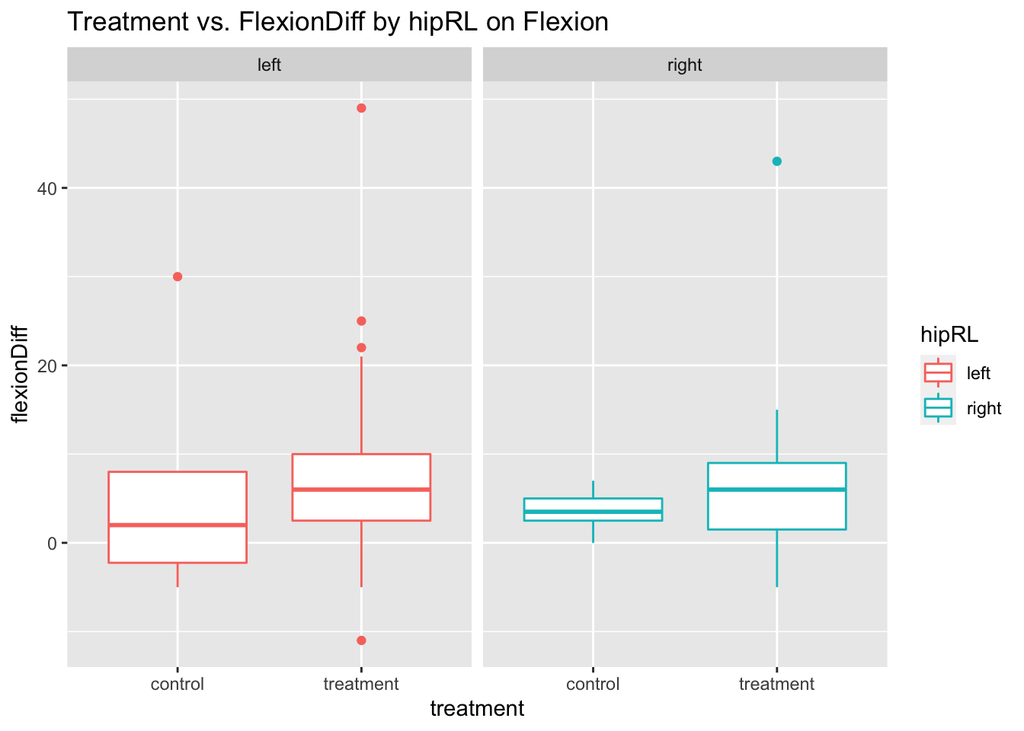

There is no significant difference between left and right hip. There is a slightly improvement between control and treatment groups on flexion.

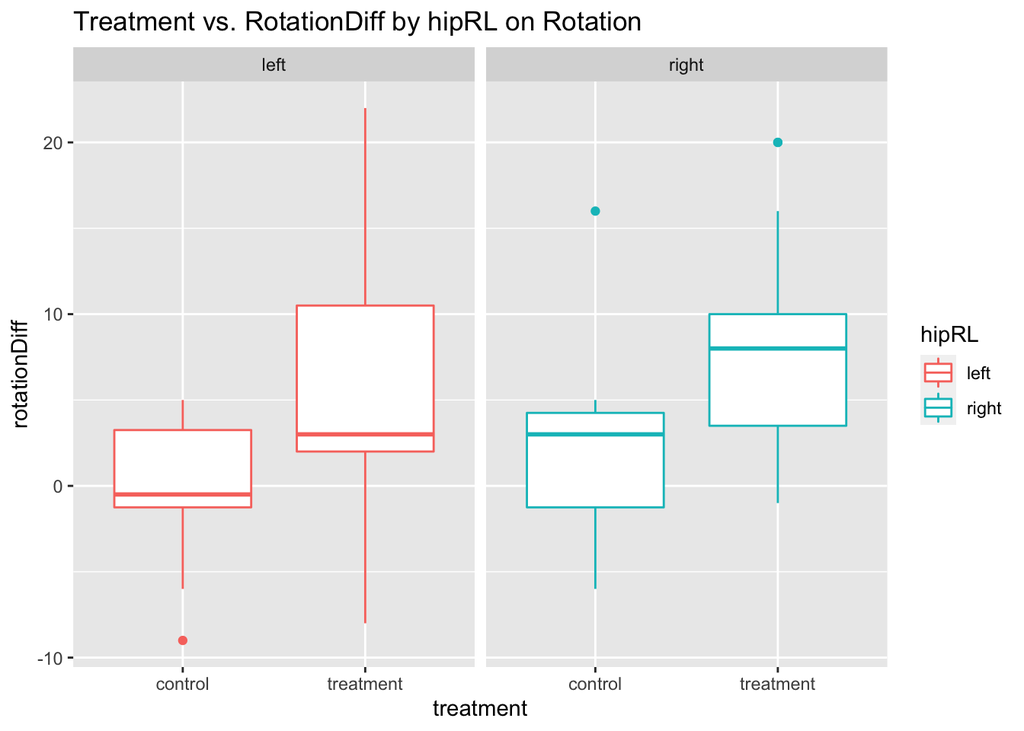

There is no significant difference between left and right hips, but there is a improvement between control groups and treatment groups on rotation.

From figure1 and figure2, we can’t see a significant difference between right/left hips in both groups. However, based on the plot we can clearly see there is a improvement between control and treatment groups on rotation and a slightly difference on flexion. While it seems like treatment groups have more improvement than control groups, further models need to be tested.

Then we also looked at the correlation between left and right hips on before, after and difference data to see if they are highly correlated (See Appendix B fig2). Even though from correlation plots between left and right hips shows they are not strongly correlated in some cases, we still concluded that left and right hip are not independent cases for each patient. Every patient has two hips and one of them would be the dominate hip, two hips from one patients should not be independent from each other in our study.

Then we looked at the descriptive summary statistics, shown in Table2.

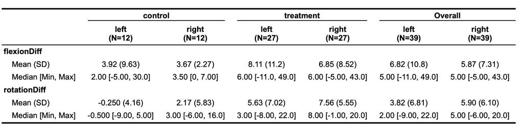

In Table2, in order to make the experiment more precise, we created this table that regards each hip as a unique unit. If we first look at the control group, there is no significance between left or right hips. However, it is slightly showing toward rotation, right hips improved more than left hips which are 7.56 compares to 5.63 on treatment group and 2.17 compares to -0.250 on control groups. When we look at left and right hips as a group, treatment groups get better improvement scores on both flexion and rotation tests. In addition, there is still no significant difference between right or left hips. Variability of rotation in the treatment group is larger than in the control group in generally.

# Statistical Analysis

### Final models

Considering the model both have fixed parts such as treatment however also should take random parts such as patient number, right/left. We finally decided to use a mixed effect model. When difference in flexion as a responsible variable, treatment as fixed effect, while hip, flexionBefore and patient as random effect, we found intraclass correlation coefficient(ICC) on hip is -0.0208 which means almost nothing related with improvement scores. So we removed that and remained patient and flexionBefore they have nearly 0.6 ICC score. The model is $lmer(flexdiff \sim treatment + (1|flexionBefore) + (1|patientNo) )$ (see appendix D). Besides, we use ANOVA to compare full models which include treatment while the null model does not, and the result is the same as before, treatment should remain on the table(see appendix D). We use the same method to rotation, this we not only eliminate hip as a random effect but also eliminate rotationBefore as their ICC scores are 0.0253 and 0.087. The final model for rotation would be $lmer(rotadiff \sim treatment + (1|patinetNo))$ (see appendix D) for the ANOVA comparison, we should still include treatment as it’s p-value is smaller than 0.05 which is 0.00393.

### ANOVA MODEL for Flexion Difference

```
## refitting model(s) with ML (instead of REML)
```

|  | npar | AIC | BIC | logLik | deviance | Chisq | Df | Pr(>Chisq) |
| --- | --- | --- | --- | --- | --- | --- | --- | --- |
| flexionModel.null | 4 | 548.7891 | 558.2159 | -270.3945 | 540.7891 | NA | NA | NA |
| flexionModel.full | 5 | 543.1552 | 554.9388 | -266.5776 | 533.1552 | 7.633867 | 1 | 0.005728237 |

From the ANOVA test for flexionDiff model selection, the p-value of full model, which includes treatment as an explanatory variable is 0.005728. In conclusion, treatment has significant influence on the flexion difference.

### ANOVA MODEL for Rotation Difference

```
## refitting model(s) with ML (instead of REML)
```

|  | npar | AIC | BIC | logLik | deviance | Chisq | Df | Pr(>Chisq) |
| --- | --- | --- | --- | --- | --- | --- | --- | --- |
| rotationModel.null | 3 | 493.6789 | 500.7491 | -243.8395 | 487.6789 | NA | NA | NA |
| rotationModel.full | 4 | 487.3671 | 496.7939 | -239.6835 | 479.3671 | 8.311852 | 1 | 0.003938722 |

From the ANOVA test for rotationDiff model selection, the p-value of treatment is 0.003939. In conclusion, treatment has significant influence on the rotation difference.

# Recommendations

The main research questions our client wanted to answer was “Does additional stretch help patients to get more movement in their hip joints?”

# Resources

**R-Packages:**

car: John Fox and Sanford Weisberg (2019). An {R} Companion to Applied Regression, Third Edition. Thousand Oaks CA: Sage. URL: https://socialsciences.mcmaster.ca/jfox/Books/Companion/

data.table: Matt Dowle and Arun Srinivasan (2020). data.table: Extension of `data.frame`. R package version 1.13.0. https://CRAN.R-project.org/package=data.table

dplyr: Hadley Wickham, Romain François, Lionel Henry and Kirill Müller (2020). dplyr: A Grammar of Data Manipulation. R package version 1.0.1. https://CRAN.R-project.org/package=dplyr

ggplot2: H. Wickham. ggplot2: Elegant Graphics for Data Analysis. Springer-Verlag New York, 2016.

ggpubr: Alboukadel Kassambara (2020). ggpubr: 'ggplot2' Based Publication Ready Plots. R package version 0.4.0. https://CRAN.R-project.org/package=ggpubr

ICC: M.E. Wolak, D.J. Fairbairn, Y.R. Paulsen (2012) Guidelines for Estimating Repeatability. Methods in Ecology and Evolution 3(1):129-137.

lmerTest: Kuznetsova A, Brockhoff PB, Christensen RHB (2017). “lmerTest Package: Tests in Linear Mixed Effects Models.” *Journal of Statistical Software*, *82*(13), 1-26. doi: 10.18637/jss.v082.i13 (URL: https://doi.org/10.18637/jss.v082.i13).

Lme4: Douglas Bates, Martin Maechler, Ben Bolker, Steve Walker (2015). Fitting Linear Mixed-Effects Models Using lme4. Journal of Statistical Software, 67(1), 1-48. doi:10.18637/jss.v067.i01.

Matrix: Douglas Bates and Martin Maechler (2019). Matrix: Sparse and Dense Matrix Classes and Methods. R package version 1.2-18. https://CRAN.R-project.org/package=Matrix

phia: Helios De Rosario-Martinez (2015). phia: Post-Hoc Interaction Analysis. R package version 0.2-1. https://CRAN.R-project.org/package=phi

readr: Hadley Wickham, Jim Hester and Romain Francois (2018). readr: Read Rectangular Text Data. R package version 1.3.1. https://CRAN.R-project.org/package=readr

stringr: Hadley Wickham (2019). stringr: Simple, Consistent Wrappers for Common String Operations. R package version 1.4.0. https://CRAN.R-project.org/package=stringr

table1: Benjamin Rich (2020). table1: Tables of Descriptive Statistics in HTML. R package version 1.2. https://CRAN.R-project.org/package=table1

tidyr: Hadley Wickham and Lionel Henry (2020). tidyr: Tidy Messy Data. R package version 1.1.1. https://CRAN.R-project.org/package=tidyr

# Additional Considerations

During the project, we noticed there are some limitations need further discussion. First of all, the raw dataset which is provided by RHN is missing lots of important variables that may be a serious confounder such as age. In general, younger age patients may improve better than the elder even if they are in both treatment groups. And usually we will assume there is an age limitation range for this clinic trial study, however as RHN did not provide, we have sufficient reason to question the autheitch of the data.

Second, the severe level of AS symptoms wasn't provided and this kind of initial situation should be given. Statistical analytic may have many uncertainties because of these missing characters. For example, a light symptom patient won’t have as much improvement as a serious symptom can get, on the other hand, an extremely awful symptom may only be healed by surgery not stretching only. Without these information provided, we can’t have a strong conclusion.

Third, RHN didn’ t mention anything about dominating hips. As we all know, humans have preferences on the right or left hand/leg. What if the hip also has a dominant one? Will it be an improvement much more than the other side? We cannot rule out dominating hip as a variable involved in our data analytic.

*We would like to thank the thirty nine patients and Royal National Hospital for the opportunity to work on this project. We enjoyed it and hope our results could be helpful to help more Ankylosing spondylitis patients.*

# Technical Appendix

## Appendix A: Raw Data Description

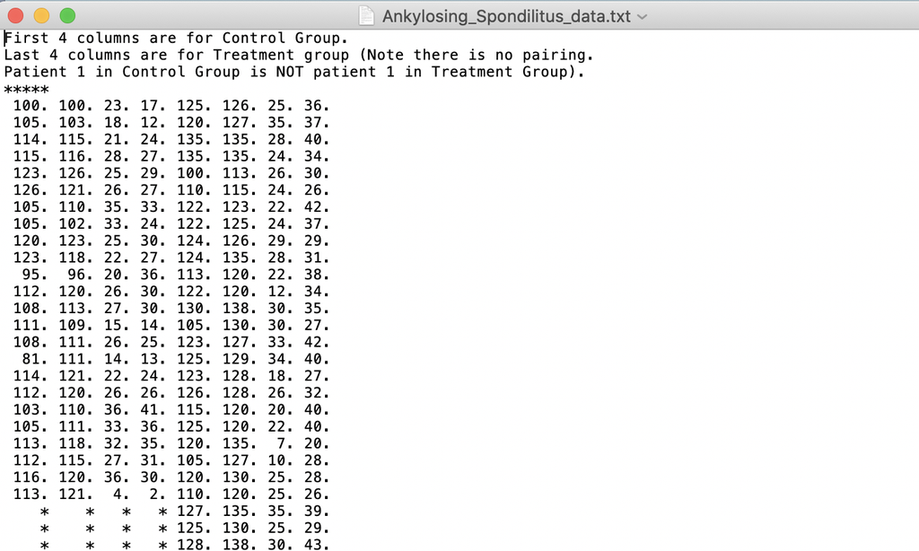

## Appendix B: Additional Tables and Figures used for EDA

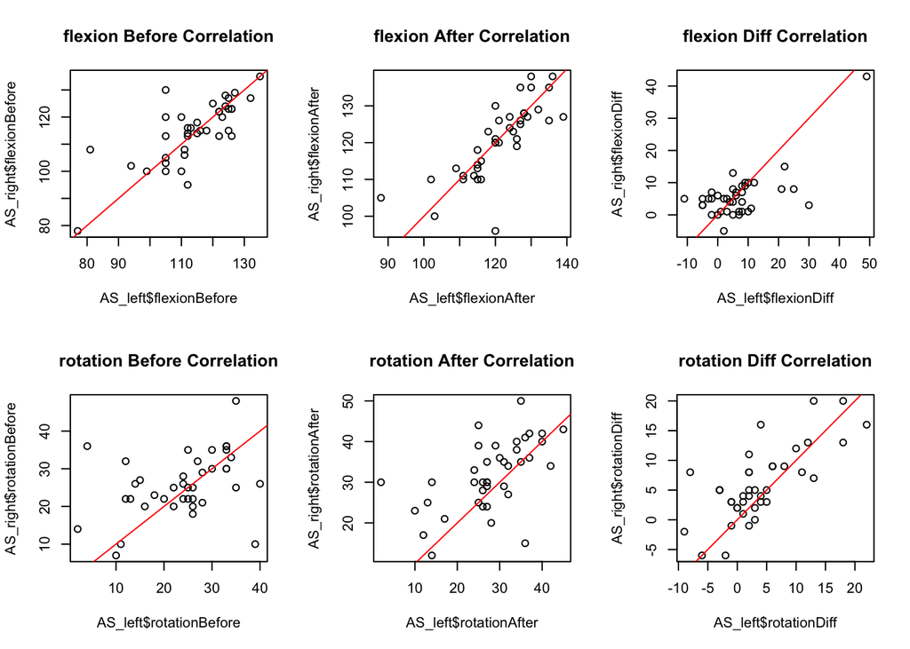

We noticed that left and right hips are more correlated on flexion compares to rotation. Left and right hips are least correlated on rotationBefore and highest correlated on flexionAfter.

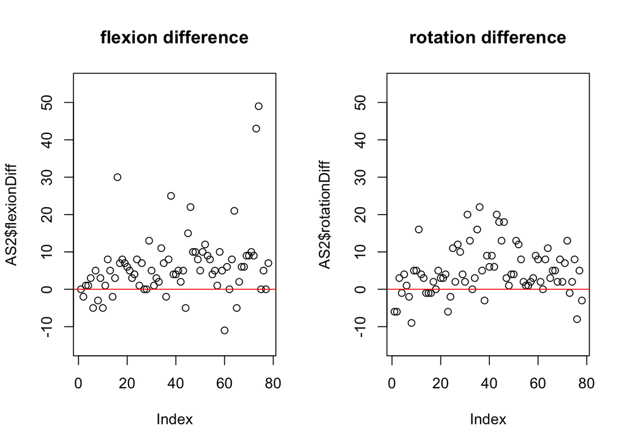

## Appendix C: Linear Mixed Effect Model Assumptions and Verification

- Assumption 1: Linearity: there is a relationship between the variables, we can conclude that from the model summary in Appendix D.
- Assumption 2: Independence: Since the patients from this experiment are randomly allocated to treatment groups, we can assume the independence.
- Assumption 3: The errors, at each set of values of the predictors, are normally distributed: Through the QQ plots (see Appendix D), we can see the data follow around the straight line, which suggest the residuals are normally distributed.
- Assumption 4: The errors, at each set of values of the predictors, have equal variance: Through the residuals v.s fitted value plot (see Appendix D), we can see the data does not have a pattern to the fitted value. We can conclude that the variance in the error terms is constant.

## Appendix D: Addition information for Modeling

### Modeling for Flexion

```r
# initial model
flexionModel1 = lmer(flexionDiff ~ treatment + (1|hipRL) + (1|flexionBefore) + (1|patientNo),
                     data = AS2)
```

```
## boundary (singular) fit: see ?isSingular
```

```r
summary(flexionModel1)
```

```
## Linear mixed model fit by REML. t-tests use Satterthwaite's method [
## lmerModLmerTest]
## Formula: flexionDiff ~ treatment + (1 | hipRL) + (1 | flexionBefore) +
##     (1 | patientNo)
##    Data: AS2
##
## REML criterion at convergence: 526.8
##
## Scaled residuals:
##      Min       1Q   Median       3Q      Max
## -1.75344 -0.34245  0.05624  0.30423  1.44612
##
## Random effects:
##  Groups        Name        Variance Std.Dev.
##  patientNo     (Intercept) 24.338   4.933
##  flexionBefore (Intercept) 84.292   9.181
##  hipRL         (Intercept)  0.000   0.000
##  Residual                   8.087   2.844
## Number of obs: 78, groups:  patientNo, 39; flexionBefore, 32; hipRL, 2
##
## Fixed effects:
##                    Estimate Std. Error     df t value Pr(>|t|)
## (Intercept)           2.903      2.378 56.617   1.221  0.22717
## treatmenttreatment    6.326      2.089 19.931   3.029  0.00665 **
## ---
## Signif. codes:  0 '***' 0.001 '**' 0.01 '*' 0.05 '.' 0.1 ' ' 1
##
## Correlation of Fixed Effects:
##             (Intr)
## trtmnttrtmn -0.617
## optimizer (nloptwrap) convergence code: 0 (OK)
## boundary (singular) fit: see ?isSingular
```

```r
# checking ICC for random effects
ICCbare(hipRL,flexionDiff, AS2)
```

```
## [1] -0.02078621
```

```r
ICCbare(patientNo, flexionDiff, AS2)
```

```
## [1] 0.6270388
```

```r
ICCbare(flexionBefore,flexionDiff, AS2)
```

```
## [1] 0.6389288
```

```r
# final model
flexionModel2 = lmer(flexionDiff ~ treatment + (1|flexionBefore) + (1|patientNo), data = AS2)
summary(flexionModel2)
```

```
## Linear mixed model fit by REML. t-tests use Satterthwaite's method [
## lmerModLmerTest]
## Formula: flexionDiff ~ treatment + (1 | flexionBefore) + (1 | patientNo)
##    Data: AS2
##
## REML criterion at convergence: 526.8
##
## Scaled residuals:
##      Min       1Q   Median       3Q      Max
## -1.75345 -0.34245  0.05624  0.30422  1.44613
##
## Random effects:
##  Groups        Name        Variance Std.Dev.
##  patientNo     (Intercept) 24.337   4.933
##  flexionBefore (Intercept) 84.293   9.181
##  Residual                   8.087   2.844
## Number of obs: 78, groups:  patientNo, 39; flexionBefore, 32
##
## Fixed effects:
##                    Estimate Std. Error     df t value Pr(>|t|)
## (Intercept)           2.903      2.378 56.617   1.221  0.22717
## treatmenttreatment    6.326      2.089 19.931   3.029  0.00665 **
## ---
## Signif. codes:  0 '***' 0.001 '**' 0.01 '*' 0.05 '.' 0.1 ' ' 1
##
## Correlation of Fixed Effects:
##             (Intr)
## trtmnttrtmn -0.617
```

```r
coefficients(flexionModel2)
```

```
## $patientNo
##    (Intercept) treatmenttreatment
## 1   -4.2052013           6.326012
## 2    1.3185534           6.326012
## 3    5.1542071           6.326012
## 4   -3.0337550           6.326012
## 5    1.5995038           6.326012
## 6    5.6783124           6.326012
## 7    4.0841156           6.326012
## 8    5.0095124           6.326012
## 9    6.3535143           6.326012
## 10   1.8011520           6.326012
## 11   3.6289722           6.326012
## 12   7.4486006           6.326012
## 13   1.4182641           6.326012
```

[output cut: 64 more lines]

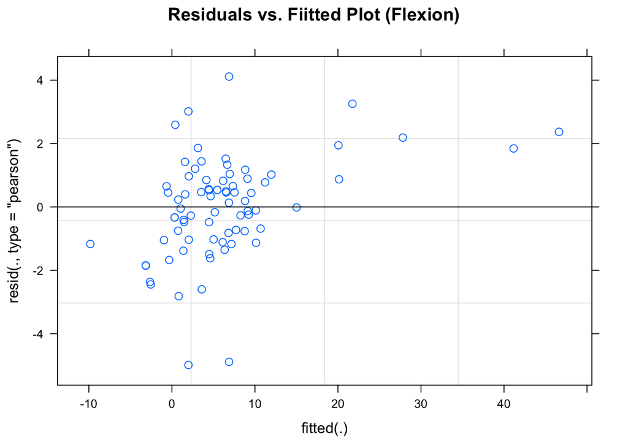

```r
# residual plots
plot(flexionModel2, main = "Residuals vs. Fiitted Plot (Flexion)")
```

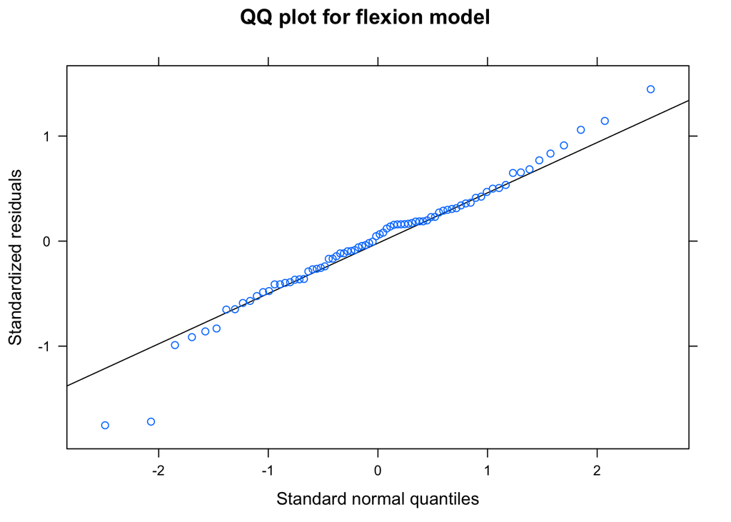

```r
qqmath(flexionModel2, main = "QQ plot for flexion model")
```

### Modeling for Rotation

```r
# initial model
rotationModel1 = lmer(rotationDiff ~ treatment + (1|hipRL) + (1|rotationBefore) + (1|patientNo),
                      data = AS2)
summary(rotationModel1)
```

```
## Linear mixed model fit by REML. t-tests use Satterthwaite's method [
## lmerModLmerTest]
## Formula: rotationDiff ~ treatment + (1 | hipRL) + (1 | rotationBefore) +
##     (1 | patientNo)
##    Data: AS2
##
## REML criterion at convergence: 470.5
##
## Scaled residuals:
##      Min       1Q   Median       3Q      Max
## -2.39052 -0.35585  0.00346  0.40386  1.90583
##
## Random effects:
##  Groups         Name        Variance Std.Dev.
##  patientNo      (Intercept) 23.671   4.865
##  rotationBefore (Intercept)  1.268   1.126
##  hipRL          (Intercept)  1.695   1.302
##  Residual                   10.338   3.215
## Number of obs: 78, groups:  patientNo, 39; rotationBefore, 30; hipRL, 2
##
## Fixed effects:
##                    Estimate Std. Error     df t value Pr(>|t|)
## (Intercept)           1.016      1.828  9.595   0.556  0.59093
## treatmenttreatment    5.587      1.878 35.285   2.974  0.00527 **
## ---
## Signif. codes:  0 '***' 0.001 '**' 0.01 '*' 0.05 '.' 0.1 ' ' 1
##
## Correlation of Fixed Effects:
##             (Intr)
## trtmnttrtmn -0.711
```

```r
# checking ICC for random effects
ICCbare(hipRL, rotationDiff, AS2)
```

```
## [1] 0.02532309
```

```r
ICCbare(rotationBefore, rotationDiff, AS2)
```

```
## [1] 0.08732881
```

```r
ICCbare(patientNo, rotationDiff, AS2)
```

```
## [1] 0.6929554
```

```r
# final model
rotationModel2 = lmer(rotationDiff ~ treatment + (1|patientNo),data = AS2)
summary(rotationModel2)
```

```
## Linear mixed model fit by REML. t-tests use Satterthwaite's method [
## lmerModLmerTest]
## Formula: rotationDiff ~ treatment + (1 | patientNo)
##    Data: AS2
##
## REML criterion at convergence: 474.7
##
## Scaled residuals:
##      Min       1Q   Median       3Q      Max
## -2.60685 -0.41990 -0.04216  0.47169  2.20239
##
## Random effects:
##  Groups    Name        Variance Std.Dev.
##  patientNo (Intercept) 23.45    4.842
##  Residual              13.12    3.622
## Number of obs: 78, groups:  patientNo, 39
##
## Fixed effects:
##                    Estimate Std. Error      df t value Pr(>|t|)
## (Intercept)          0.9583     1.5813 37.0000   0.606  0.54819
## treatmenttreatment   5.6343     1.9005 37.0000   2.965  0.00528 **
## ---
## Signif. codes:  0 '***' 0.001 '**' 0.01 '*' 0.05 '.' 0.1 ' ' 1
##
## Correlation of Fixed Effects:
##             (Intr)
## trtmnttrtmn -0.832
```

```r
coefficients(rotationModel2)
```

```
## $patientNo
##    (Intercept) treatmenttreatment
## 1   -4.4793192           5.634259
## 2    0.9908941           5.634259
## 3    2.1630827           5.634259
## 4   -4.0885897           5.634259
## 5    4.1167303           5.634259
## 6    8.0240256           5.634259
## 7    0.9908941           5.634259
## 8   -0.5720240           5.634259
## 9    0.9908941           5.634259
## 10   3.3352713           5.634259
## 11   2.9445418           5.634259
## 12  -2.9164011           5.634259
## 13   0.8859760           5.634259
```

[output cut: 29 more lines]

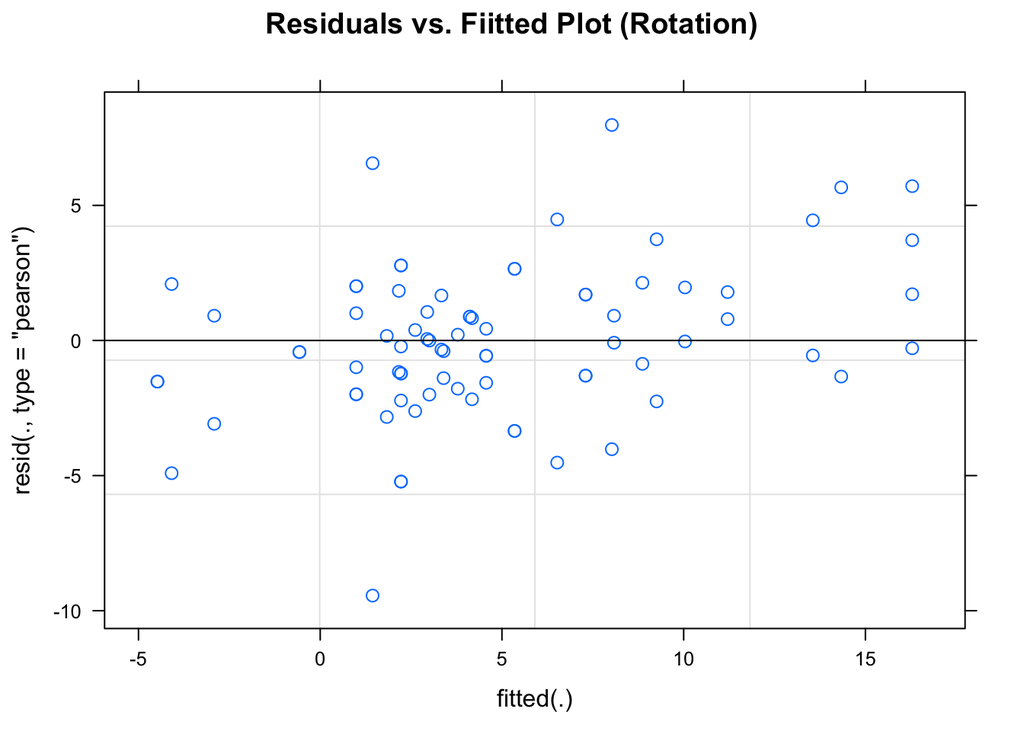

```r
# residual plots
plot(rotationModel2, main = "Residuals vs. Fiitted Plot (Rotation)")
```

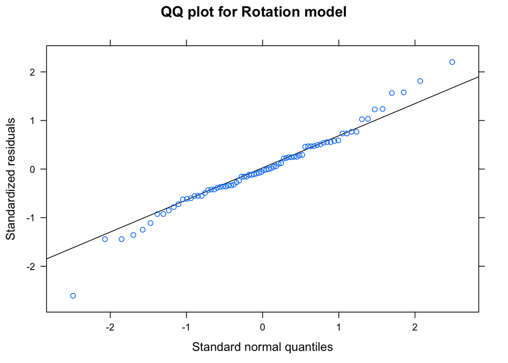

```r
qqmath(rotationModel2, main = "QQ plot for Rotation model")
```

## R Script

```r
# clean up & set default chunk options
rm(list = ls())
knitr::opts_chunk$set(echo = FALSE)

#library
library(data.table)
library(stringr)
library(readr)
library(table1)
library(ggplot2)
library(car)
library(phia)
library(ggpubr)
library(dplyr)
library(tidyr)
library(lmerTest)
library(ICC)
library(lme4)
library(Matrix)
library(lattice)

# user-defined functions

#Read in dataset
AS = read_csv("Ankylosing_Spondilitus_data_clean.csv")
# data preprocessing
AS2 = AS
AS2$flexionDiff = AS2$flexionAfter - AS2$flexionBefore
AS2$rotationDiff = AS2$rotationAfter - AS2$rotationBefore
# Check missing value
sum(is.na(AS2))
# Check if there are situation one increase while the other decrease
AS2$BothInc<-ifelse(AS2$flexionDiff<0 & AS2$rotationDiff>0, FALSE,
                    ifelse(AS2$flexionDiff>0 & AS2$rotationDiff<0, FALSE, TRUE))
summary(AS2$BothInc)
#box plots for flexiondiff
ggplot(AS2, aes(x=treatment,y=flexionDiff)) +
  geom_boxplot(aes(color=hipRL)) +
  facet_grid(.~hipRL,scales = "free_x") +
  ggtitle("Treatment vs. FlexionDiff by hipRL on Flexion")
#box plots for rotationdiff
ggplot(AS2, aes(x=treatment,y=rotationDiff)) +
  geom_boxplot(aes(color=hipRL)) +
  facet_grid(.~hipRL,scales = "free_x") +
  ggtitle("Treatment vs. RotationDiff by hipRL on Rotation")
#summary statistics table
table1(~flexionDiff+rotationDiff | treatment*hipRL, data=AS2)
#correlation plots
AS_left = AS2[which(AS$hipRL=='left'),]
AS_right = AS2[which(AS$hipRL=='right'),]
par(mfrow=c(2,3))
plot(AS_left$flexionBefore, AS_right$flexionBefore, main="flexion Before Correlation")
abline(0,1,col="red")
plot(AS_left$flexionAfter, AS_right$flexionAfter, main="flexion After Correlation")
abline(0,1,col="red")
plot(AS_left$flexionDiff, AS_right$flexionDiff, main="flexion Diff Correlation")
abline(0,1,col="red")

plot(AS_left$rotationBefore, AS_right$rotationBefore, main="rotation Before Correlation")
abline(0,1,col="red")
plot(AS_left$rotationAfter, AS_right$rotationAfter, main="rotation After Correlation")
abline(0,1,col="red")
plot(AS_left$rotationDiff, AS_right$rotationDiff, main="rotation Diff Correlation")
abline(0,1,col="red")
#difference scatter plots
par(mfrow=c(1,2))
plot(AS2$flexionDiff, ylim = c(-15,55), main = "flexion difference")
abline(h=0,col="red")
plot(AS2$rotationDiff, ylim = c(-15,55), main = "rotation difference")
abline(h=0,col="red")
#anova model for flexion difference
flexionModel.full = lmer(flexionDiff ~ treatment + (1|flexionBefore) + (1|patientNo), data = AS2)
flexionModel.null = lmer(flexionDiff ~  (1|flexionBefore) + (1|patientNo), data = AS2)
anova(flexionModel.full,flexionModel.null)
#anova model for rotation difference
rotationModel.full = lmer(rotationDiff ~ treatment + (1|patientNo),data = AS2)
rotationModel.null = lmer(rotationDiff ~ (1|patientNo),data = AS2)
anova(rotationModel.full,rotationModel.null)
```